# Mapping habitat loss to urban expansion

James Hutchison, Catherine Hudson and Damien Hicks

8 June 2018

## Introduction

Version 1 of this report gave the preliminary results from some work carried out to evaluate whether comparing the high-resolution, 25m pixel versions of Land Cover Map (LCM) 2007 and LCM 2015 would enable us to accurately assess the area of different habitats lost to urban expansion in the time period between the two maps, and whether the method could provide insight into the size and spatial distribution of the developments contributing to this habitat loss. The initial work identified issues caused by classification method changes between the two LCM layers, which created a large number of erroneious changes to urban landcover types from other non-urban land covers. This report describes the results of further work carried out to constrain the analysis by using postcode changes as a proxy for new housing developments.

As with the first version, the analysis aims to address two key questions:

1. What habitats have been lost to urban expansion between 2007 and 2015?
2. What size of developments have caused these loses?

The report tackles these two questions in turn. Details of the methods and data layers used have been moved to the end.

## Question 1: What are the changes between LCM 2007 and 2015?

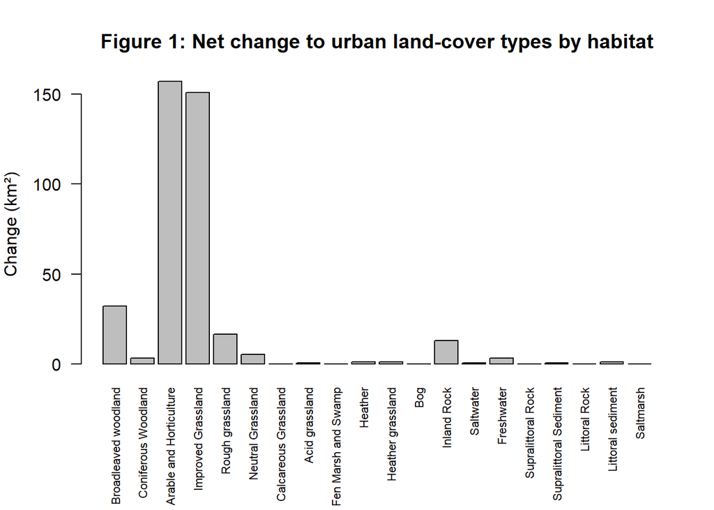

Using postcodes to constrain the analysis has reduced the area of habitats lost by approximately two thirds. However, the proportion of those losses from each land cover type remains fairly similar. The majority of urban expansion has come at the expense of improved grassland and arable. Of the semi-natural land cover types, rough grassland and broadleaved woodland have seen the greatest conversion to urban developments. The high figure for inland rock is surprising, but may be due to groundworks in the early phases of developments in the satellite imagery used for LCM 2007 being erroneously classed as inland rock - a quick check of a few sites showing this change on Google maps seems to support this.

# Loses as a proportion of overall area

More interesting than the total loss of each land cover type is the proportion of each that has been lost to development, on both national and regional scales.

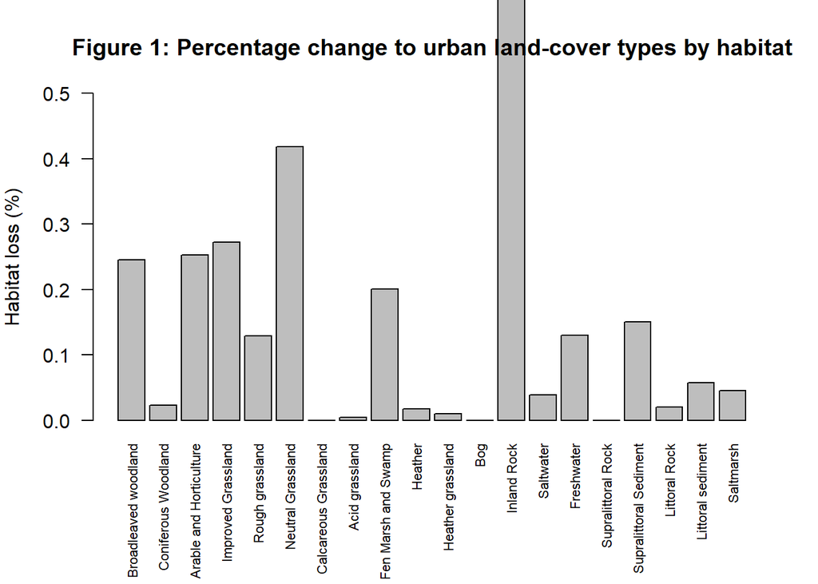

Inland rock stands out again, but as discussed above I believe this is an artifcact due to misclassification of groundworks at the early stages of development. Aside from the that, neutral grassland has the highest percentage loss despite a relatively small absolute loss of area, due to its comparative rarity. This is followed by improved grassland, arable and horticulture and broadleaved woodland, which are the habitats with the greatest total loss of area.

# Regional breakdown

We can get a better feel for where in the country these loses are occuring by breaking the numbers down by region. For this example we use the EA and NE 14 public-facing areas. First we can look at which regions have the largest total losses.

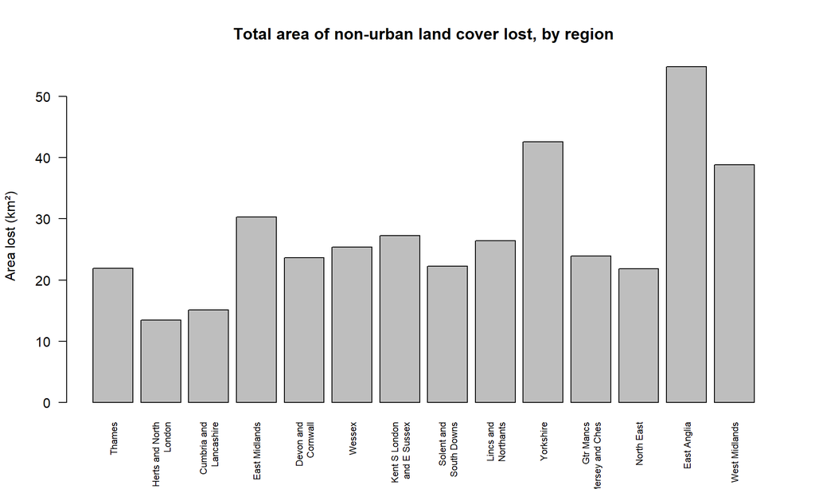

This shows that the largest losses have been in East Anglia, Yorkshire and the West Midlands. Herts and North London has experienced the smallest loss, likely because it is a much more urbanised region so has less non-urban areas to lose. We can explore this further by looking at the losses as a proportion of total non-urban area in each region, and as a proportion of the total area of the region as a whole.

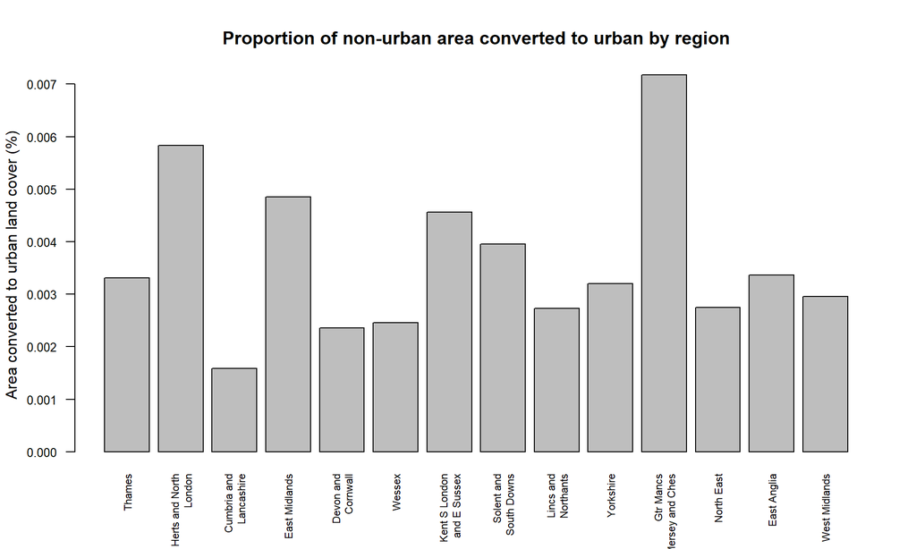

This shows that despite having the largest absolute losses, East Anglia and Yorkshire have comparatively small percentage losses, reflecting the fact that they are large regions with small areas of existing urban land cover. The regions with the largest percentage change are Greater Manchester, Merseyside and Cheshire, and Herts and North London, both of which are relatively small regions with high levels of existing urban land cover, meaning that even relatively small losses of non-urban areas in absolute terms make up a larger percetage of the total non-urban area.

# Regional losses by land cover type

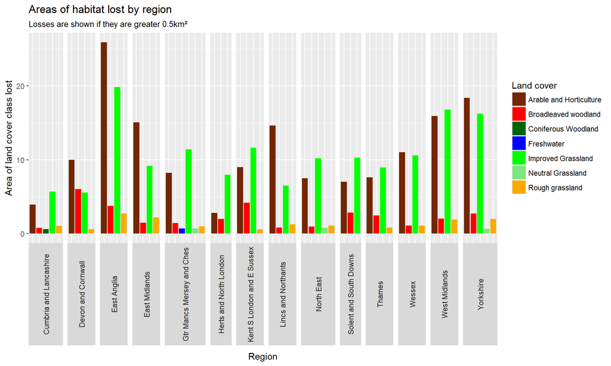

## Question 2: How big are the developments causing these losses

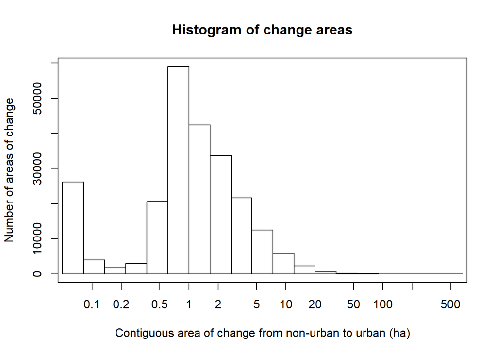